# Frequency Analysis Lab Report2

## Data sources and format

Sources compared in this report:

- RND 360-00002 Arbitrary Waveform Generator (AWG)
- Keysight oscilloscope built‑in Function Generator (FG)

All comparisons are presented in dBVrms.

Data files and format:

- RND_lab_*: FFTs of signals from the RND AWG
- trace_*_fft.csv: FFT traces using the Keysight FG
- rc_fft_*: FFTs through an RC filter (used when noted)
- CSVs use semicolon delimiter and comma decimals; last two columns are [frequency (Hz), magnitude]

```python
# Utility: Load FFT CSV exported by Keysight/DSOX (semicolon delimiter, comma decimals)
# Returns a DataFrame with columns: freq_hz, magnitude (Vrms), and dBVrms
from __future__ import annotations
import pandas as pd
import numpy as np
from pathlib import Path


def load_fft_csv(path: str | Path, *, add_db: bool = True) -> pd.DataFrame:
    """
    Load an FFT CSV with Keysight export format (RND_lab_*, rc_fft_*, trace_*_fft.csv).

    - Delimiter: ';'
    - Decimal separator: ','
    - Metadata lines may precede numeric data; numeric data ends up in the last two columns.

    Returns a DataFrame with:
        freq_hz (float), magnitude (Vrms, float), and optionally dBVrms (20*log10(Vrms)).
    """
    path = Path(path)
    # Use python engine for flexible parsing; do not pass low_memory (unsupported by python engine)
    df = pd.read_csv(path, sep=';', decimal=',', header=None, engine='python')

    # Convert all columns to numeric where possible
    num = df.apply(pd.to_numeric, errors='coerce')

    # Identify columns that are mostly numeric; keep the last two such columns
    numeric_cols = [c for c in num.columns if num[c].notna().sum() > 0]
    if len(numeric_cols) < 2:
        raise ValueError(f"Could not find two numeric columns in {path}")

    c2, c1 = numeric_cols[-1], numeric_cols[-2]  # last two numeric columns
    out = num[[c1, c2]].rename(columns={c1: 'freq_hz', c2: 'magnitude'})

    # Clean rows: drop NaNs and non-positive frequencies
    out = out.dropna()
    out = out[out['freq_hz'] > 0]

    if add_db:
        # Guard against zeros/negatives for dB conversion; CSV magnitudes are Vrms
        mag = out['magnitude'].clip(lower=np.finfo(float).eps)
        out['dBVrms'] = 20 * np.log10(mag)
        # Back-compat alias if any legacy cell expects this name
        out['magnitude_db'] = out['dBVrms']

    # Sort by frequency just in case
    out = out.sort_values('freq_hz').reset_index(drop=True)
    return out


# Tiny smoke check (no execution here):
# d = load_fft_csv('RND_lab_sine_1khz_fft.csv')
# d.head()
```

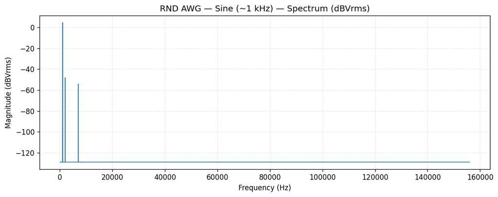

```python
# Example: load and plot an RND_lab FFT (1 kHz sine) in dBVrms
import matplotlib.pyplot as plt

fft = load_fft_csv('RND_lab_sine_1khz_fft.csv', add_db=True)

plt.figure(figsize=(10, 4))
plt.plot(fft['freq_hz'], fft['dBVrms'], lw=1.0)
plt.title('RND AWG — Sine (~1 kHz) — Spectrum (dBVrms)')
plt.xlabel('Frequency (Hz)')
plt.ylabel('Magnitude (dBVrms)')
plt.grid(True, which='both', ls=':', alpha=0.5)
plt.tight_layout()
plt.show()
```

## Generator quality comparison: RND AWG vs Keysight FG

We compare the RND 360-00002 AWG against the Keysight oscilloscope’s built‑in function generator for three waveforms:

- Sine (≈1 kHz)
- Triangle
- Sawtooth

All comparisons are presented in dBVrms, with separate graphs for each generator to keep the view simple.

Reported (optional) metrics shown elsewhere:

- Fundamental frequency and level (dBVrms)
- THD (Total Harmonic Distortion) in dB
- SFDR (Spurious‑Free Dynamic Range) in dB
- Noise floor (median, dBVrms)

```python
import numpy as np
import pandas as pd
from typing import Dict, Tuple


def to_dbv(df: pd.DataFrame, floor_vrms: float = 1e-12) -> pd.DataFrame:
    """Convert magnitude (assumed RMS voltage) to dBVrms (20*log10(Vrms/1V))."""
    d = df.copy()
    mag = d['magnitude'].clip(lower=floor_vrms)
    d['dBVrms'] = 20 * np.log10(mag)
    return d


def find_fundamental_dbv(d: pd.DataFrame, fmin: float = 1.0) -> Tuple[float, float]:
    """Return (f0, dBVrms0) for max amplitude above fmin."""
    dd = d[d['freq_hz'] >= fmin]
    i = dd['dBVrms'].idxmax()
    return float(dd.loc[i, 'freq_hz']), float(dd.loc[i, 'dBVrms'])


def metric_thd_db(d_raw: pd.DataFrame, f0: float, nharm: int = 10) -> float:
    """THD in dB using RMS amplitudes: 20log10( sqrt(sum_{k>=2} Ak^2) / A1 )."""
    # Use linear Vrms for THD
    A1 = d_raw[d_raw['freq_hz'].between(0.98 * f0, 1.02 * f0)]['magnitude'].max()
    A1 = float(max(A1, np.finfo(float).eps))
    thd_power = 0.0
    for k in range(2, nharm + 1):
        fk = k * f0
        Ak = d_raw[d_raw['freq_hz'].between(0.995 * fk, 1.005 * fk)]['magnitude'].max()
        Ak = float(max(Ak, 0.0))
        thd_power += Ak ** 2
    thd_ratio = (thd_power ** 0.5) / A1
    thd_db = 20 * np.log10(max(thd_ratio, np.finfo(float).eps))
    return float(thd_db)


def metric_sfdr_dbv(d: pd.DataFrame, f0: float) -> float:
    """SFDR in dB relative to fundamental in dBVrms: spur_peak_dBVrms - fundamental_dBVrms (negative)."""
    fund = d[d['freq_hz'].between(0.99 * f0, 1.01 * f0)]['dBVrms'].max()
    mask = ~d['freq_hz'].between(0.99 * f0, 1.01 * f0)
    spur = d.loc[mask, 'dBVrms'].max()
    return float(spur - fund)


def metric_noise_floor_dbv(d: pd.DataFrame, f0: float) -> float:
    """Median dBVrms excluding fundamental and first 10 harmonics windows."""
    m = ~d['freq_hz'].between(0.99 * f0, 1.01 * f0)
    for k in range(2, 11):
        fk = k * f0
        m &= ~d['freq_hz'].between(0.995 * fk, 1.005 * fk)
    return float(d.loc[m, 'dBVrms'].median())


def summarize_metrics_dbv(df: pd.DataFrame) -> Dict[str, float]:
    d = to_dbv(df)
    f0, d0 = find_fundamental_dbv(d)
    return {
        'f0_hz': f0,
        'fund_dBVrms': d0,
        'THD_dB': metric_thd_db(df, f0),
        'SFDR_dB': metric_sfdr_dbv(d, f0),
        'NoiseFloorMed_dBVrms': metric_noise_floor_dbv(d, f0),
    }
```

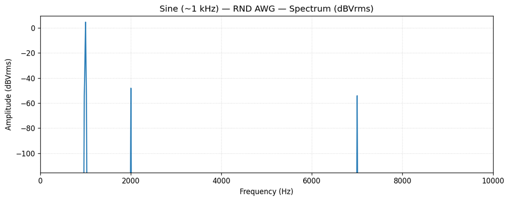

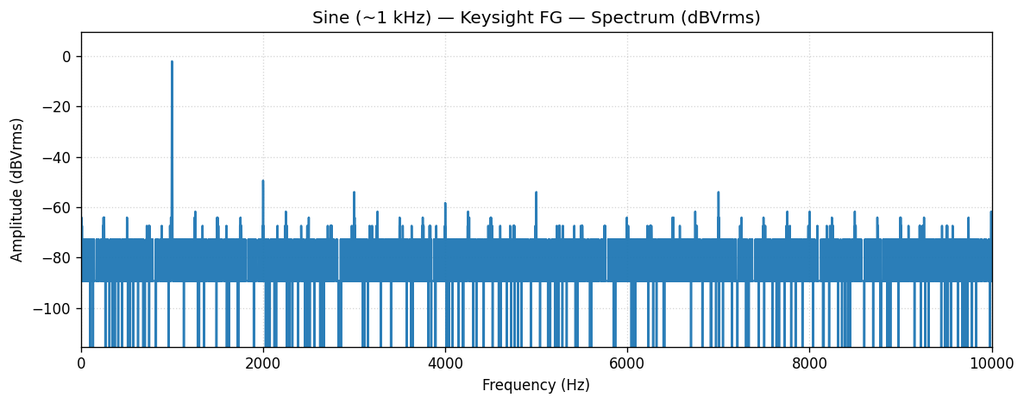

```
RND AWG — Sine (~1 kHz): f0=1001.36 Hz, Fundamental=4.5 dBVrms, THD=-51.7 dB, SFDR=-41.8 dB
Keysight FG — Sine (~1 kHz): f0=999.45 Hz, Fundamental=-2.1 dBVrms, THD=-43.6 dB, SFDR=-47.4 dB
```

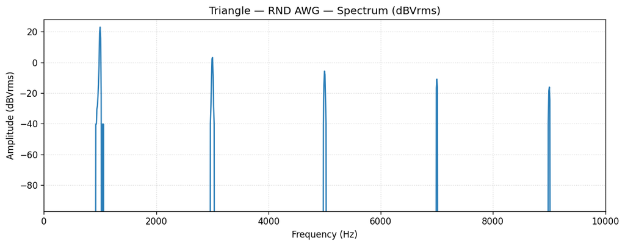

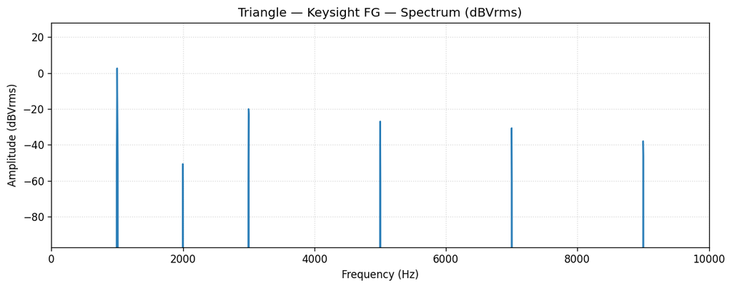

```
RND AWG — Triangle: f0=1001.36 Hz, Fundamental=23.0 dBVrms, THD=-19.1 dB, SFDR=-19.8 dB
Keysight FG — Triangle: f0=999.45 Hz, Fundamental=2.6 dBVrms, THD=-21.5 dB, SFDR=-22.7 dB
```

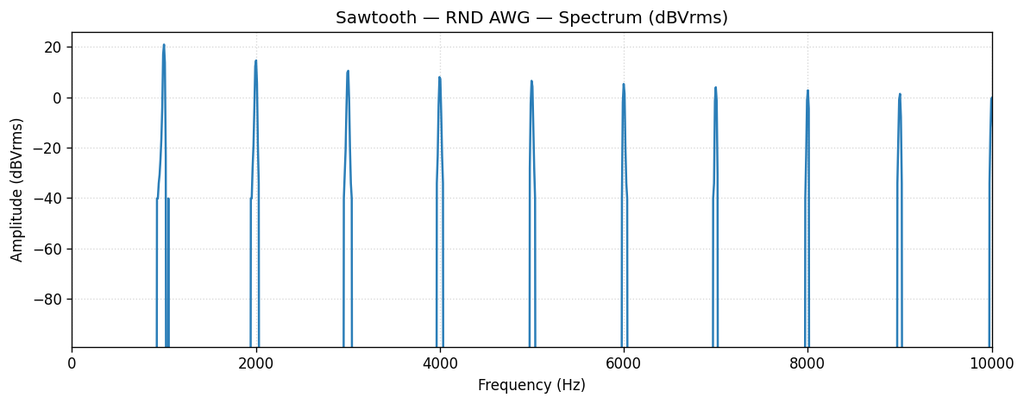

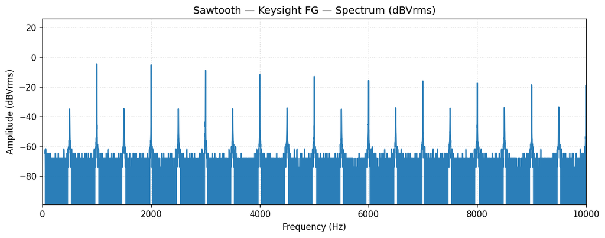

```
RND AWG — Sawtooth: f0=1001.36 Hz, Fundamental=20.9 dBVrms, THD=-3.1 dB, SFDR=-6.3 dB
Keysight FG — Sawtooth: f0=999.45 Hz, Fundamental=-4.5 dBVrms, THD=2.6 dB, SFDR=-0.6 dB
```

```python
import matplotlib.pyplot as plt
from textwrap import dedent


def plot_single_source(title: str, df_dbv, xlim=None, ylim=None):
    plt.figure(figsize=(10, 4))
    plt.plot(df_dbv['freq_hz'], df_dbv['dBVrms'], alpha=0.95)
    if xlim is None:
        xlim = (0, df_dbv['freq_hz'].max() * 0.2)
    plt.xlim(*xlim)
    if ylim is None:
        ymax = df_dbv['dBVrms'].max()
        ylim = (max(-200, ymax - 120), ymax + 5)
    plt.ylim(*ylim)
    plt.title(f"{title} — Spectrum (dBVrms)")
    plt.xlabel('Frequency (Hz)')
    plt.ylabel('Amplitude (dBVrms)')
    plt.grid(True, ls=':', alpha=0.5)
    plt.tight_layout()
    plt.show()


def _common_axes(d1, d2, f0_hint=None, n_harm=10):
    # Common x-axis: show up to ~10 harmonics if possible, bounded by both spectra span
    if f0_hint is None:
        # Estimate fundamentals from dBVrms peaks
        def est_f0(d):
            i = d['dBVrms'].idxmax()
            return float(d.loc[i, 'freq_hz'])
        f0 = 0.5 * (est_f0(d1) + est_f0(d2))
    else:
        f0 = float(f0_hint)
    target_xmax = n_harm * f0
    xmax = min(d1['freq_hz'].max(), d2['freq_hz'].max(), target_xmax)
    xlim = (0.0, max(1.0, xmax))

    # Common y-axis anchored to the larger peak
    ypeak = max(d1['dBVrms'].max(), d2['dBVrms'].max())
    ylim = (max(-200, ypeak - 120), ypeak + 5)
    return xlim, ylim


def compare_sources_separate(title: str, rnd_path: str, key_path: str):
    rnd_raw = load_fft_csv(rnd_path, add_db=True)
    key_raw = load_fft_csv(key_path, add_db=True)

    rnd = rnd_raw[['freq_hz', 'dBVrms']].copy()
    key = key_raw[['freq_hz', 'dBVrms']].copy()

    xlim, ylim = _common_axes(rnd, key, n_harm=10)

    # Separate plots with shared axes (dBVrms only)
    plot_single_source(f"{title} — RND AWG", rnd, xlim=xlim, ylim=ylim)
    plot_single_source(f"{title} — Keysight FG", key, xlim=xlim, ylim=ylim)

    # Minimal metrics print (dBVrms-based)
    m_rnd = summarize_metrics_dbv(rnd_raw.rename(columns={'magnitude': 'magnitude'}))
    m_key = summarize_metrics_dbv(key_raw.rename(columns={'magnitude': 'magnitude'}))

    def one_line(m):
        return f"f0={m['f0_hz']:.2f} Hz, Fundamental={m['fund_dBVrms']:.1f} dBVrms, THD={m['THD_dB']:.1f} dB, SFDR={m['SFDR_dB']:.1f} dB"

    print(f"RND AWG — {title}: {one_line(m_rnd)}")
    print(f"Keysight FG — {title}: {one_line(m_key)}")


def compare_two_files_separate(title_base: str, path_a: str, label_a: str, path_b: str, label_b: str, f0_hint: float | None = None):
    a_raw = load_fft_csv(path_a, add_db=True)
    b_raw = load_fft_csv(path_b, add_db=True)
    a = a_raw[['freq_hz', 'dBVrms']].copy()
    b = b_raw[['freq_hz', 'dBVrms']].copy()
    xlim, ylim = _common_axes(a, b, f0_hint=f0_hint, n_harm=10)
    plot_single_source(f"{title_base} — {label_a}", a, xlim=xlim, ylim=ylim)
    plot_single_source(f"{title_base} — {label_b}", b, xlim=xlim, ylim=ylim)


# Sine (~1 kHz)
compare_sources_separate('Sine (~1 kHz)', 'RND_lab_sine_1khz_fft.csv', 'trace_sine_fft.csv')

# Triangle
compare_sources_separate('Triangle', 'RND_lab_triangle_fft.csv', 'trace_triangle_fft.csv')

# Sawtooth
compare_sources_separate('Sawtooth', 'RND_lab_saw_fft.csv', 'trace_saw_fft.csv')
```

# Frequency Analysis – Lab Report (ELA24)

## Quick guide & structure

Tip: To reproduce the figures/tables, run the code cells in order 2, 5, 6, 13, and 14.

## 1. Introduction

A central concept in signal processing is that signals can be represented both in the time domain and in the frequency domain. Fourier series allow us to express a periodic signal as a sum of sinusoidal components. The sharper the edges in the time domain, the slower the decay of harmonic amplitudes. This experiment provides hands-on experience with Fourier analysis of canonical signals.

### Key formulas (from course compendium & lab guidance)

- **Sawtooth (all harmonics):**
  $$ A_n = \frac{2A}{\pi n}, \quad n \geq 1 $$
- **Triangle (odd harmonics only):**
  $$ A_n = \frac{8A}{\pi^2 n^2}, \quad n = 1,3,5,\dots $$
- **Sine:**
  $$ A_1 = A, \quad A_{n>1} = 0 $$
- **RMS and dBV:**
  $$ V_{\mathrm{rms}} = \frac{V_{\mathrm{peak}}}{\sqrt{2}}, \quad \mathrm{dBV} = 20 \log_{10}\!\left(\frac{V_{\mathrm{rms}}}{1~\mathrm{V}}\right) $$
- **RC low-pass transfer function:**
  $$ |H(f)| = \frac{1}{\sqrt{1 + (f/f_c)^2}}, \quad \angle H(f) = -\arctan\!\bigl(f/f_c\bigr), \quad f_c = \frac{1}{2\pi RC} $$

> **Note:** Theoretical values shown in tables and plots are computed directly from these expressions.

## 2. Experiment

### Equipment

- Signal generator: 1 kHz, **5 Vpp** (as in lab-PM), 0 V DC offset.
- Oscilloscope: Keysight/Tektronix (FFT mode, Hann window, output in dBVrms).
- RC filter:
  $$ R = 8.2\,\text{k}\Omega, \quad C = 10\,\text{nF} $$ The cutoff frequency is
  $$ f_c = \frac{1}{2\pi RC} \approx 1.94~\text{kHz} $$
- Software: Python (NumPy, Pandas, Matplotlib).

### Procedure

1. Measure first 10 harmonics of **sawtooth** (1–10 kHz) using FFT.
2. Repeat for **triangle** (expect odd harmonics only).
3. Repeat for **sine** (expect only the fundamental).
4. Insert **RC filter** and measure the sawtooth harmonics at the filter output.
5. Observe the **time-domain effect** of filtering.
6. Compare measurements to theoretical Fourier coefficients and RC transfer function.

## 3. Theory – Fourier coefficients (tables & per-signal plots)

```python
# === ELA24: Comparisons in dBVrms (no files written) ===
import numpy as np
import pandas as pd
import matplotlib.pyplot as plt
from pathlib import Path

plt.rcParams['figure.dpi'] = 120
plt.rcParams['figure.figsize'] = (7.6, 4.6)

# ----- Lab params (edit to match your setup) -----
F0      = 1000.0          # [Hz] fundamental
VPP     = 5.0             # [Vpp] generator-level for theory
A       = VPP/2.0         # [Vpeak]
N_HARM  = 10              # compare first N harmonics
R, C    = 8200.0, 10e-9   # RC low-pass values (8.2k, 10nF)
FC      = 1.0/(2*np.pi*R*C)

# ----- Helpers -----
def vrms_to_dBVrms(vrms, floor=1e-12):
    v = np.maximum(np.asarray(vrms, float), floor)
    return 20.0*np.log10(v)

def rc_mag(f, fc=FC):
    f = np.asarray(f, float)
    return 1.0/np.sqrt(1.0 + (f/fc)**2)

# ----- Fourier theory -> dBVrms -----
def sawtooth_dBVrms(n, A=A):
    n = np.asarray(n, int)
    vpk = 2.0*A/(np.pi*np.maximum(n,1))
    vrms = vpk/np.sqrt(2.0)
    return vrms_to_dBVrms(vrms)

def triangle_dBVrms(n, A=A):
    n = np.asarray(n, int)
    vrms = np.zeros_like(n, float)
    odd = (n % 2 == 1)
    vpk_odd = 8.0*A/(np.pi**2 * np.maximum(n[odd],1)**2)
    vrms[odd] = vpk_odd/np.sqrt(2.0)
    dB = vrms_to_dBVrms(vrms)
    dB[~odd] = np.nan   # even harmonics absent → NaN (not plotted)
    return dB

def sine_dBVrms(n, A=A):
    n = np.asarray(n, int)
    vrms = np.zeros_like(n, float)
    vrms[n == 1] = A/np.sqrt(2.0)   # only fundamental
    dB = vrms_to_dBVrms(vrms)
    dB[n != 1] = np.nan             # others absent
    return dB


def theory_dBVrms(F0=F0, N=N_HARM, waveform='saw', apply_rc=False):
    n = np.arange(1, N+1)
    if waveform == 'saw':
        dB = sawtooth_dBVrms(n)
    elif waveform == 'tri':
        dB = triangle_dBVrms(n)
    elif waveform == 'sin':
        dB = sine_dBVrms(n)
    else:
        raise ValueError("waveform must be 'saw' | 'tri' | 'sin'")
    if apply_rc:
        dB += vrms_to_dBVrms(rc_mag(n*F0))  # add 20*log10|H|
    return pd.DataFrame({'n': n, 'f_Hz': n*F0, 'theory_dBVrms': dB})

# ----- Scope CSV (Vrms) -> spectrum (dBVrms) -----
def read_scope_fft_vrms(csv_path):
    """
    Robust reader: handles semicolon sep, decimal comma, headers/garbage.
    Returns columns: freq[Hz], Vrms, dBVrms
    """
    raw = pd.read_csv(csv_path, sep=';', header=None, engine='python', dtype=str)
    freqs, mags = [], []
    for _, row in raw.iterrows():
        nums = []
        for cell in row.dropna():
            s = cell.strip()
            if not s:
                continue
            s = s.replace(',', '.')
            try:
                nums.append(float(s))
            except ValueError:
                pass
        if len(nums) >= 2:
            f, v = nums[-2], nums[-1]  # assume last two numeric fields = freq, Vrms
            if f >= 0 and v >= 0:
                freqs.append(f); mags.append(v)
    spec = pd.DataFrame({'freq': freqs, 'Vrms': mags}).sort_values('freq')
    spec = spec.drop_duplicates(subset=['freq']).reset_index(drop=True)
    if spec.empty:
        raise ValueError(f"No numeric data parsed from {csv_path}")
    spec['dBVrms'] = vrms_to_dBVrms(spec['Vrms'].values)
    return spec

def pick_harmonic_bins(spec_df, F0, N_HARM):
    """Nearest bin to n·F0 for n=1..N within spectrum span."""
    freqs = spec_df['freq'].values
    n_all = np.arange(1, N_HARM+1)
    targets = n_all*F0
    ok = (targets >= freqs[0]) & (targets <= freqs[-1])
    n = n_all[ok]; targets = targets[ok]
    idx = np.searchsorted(freqs, targets)
    idx = np.clip(idx, 1, len(freqs)-1)
    chosen = np.where(np.abs(freqs[idx]-targets) < np.abs(freqs[idx-1]-targets), idx, idx-1)
    return pd.DataFrame({
        'n': n,
        'f_target_Hz': targets,
        'f_bin_Hz': freqs[chosen],
        'meas_dBVrms': spec_df['dBVrms'].values[chosen],
    })

# ----- One-shot comparison plot -----
def compare_plot(csv_path, waveform, apply_rc_to_theory=False, title=None,
                 F0=F0, N=N_HARM):
    spec = read_scope_fft_vrms(csv_path)
    meas = pick_harmonic_bins(spec, F0, N)
    theo = theory_dBVrms(F0=F0, N=N, waveform=waveform, apply_rc=apply_rc_to_theory)
    df = meas.merge(theo, on='n', how='left')
    df['err_dB'] = df['meas_dBVrms'] - df['theory_dBVrms']

    plt.figure()
    plt.stem(df['n'],       df['theory_dBVrms'], linefmt='C0-', markerfmt='C0o', basefmt=" ",
             label='Theory (dBVrms)')
    plt.stem(df['n']+0.08,  df['meas_dBVrms'],   linefmt='C1-', markerfmt='C1s', basefmt=" ",
             label='Measurement (dBVrms)')
    plt.xlabel('Harmonic order n'); plt.ylabel('Amplitude [dBVrms]')
    ttl = title or f'{Path(csv_path).name} — {waveform.upper()}'
    if apply_rc_to_theory: ttl += ' (after RC, theory × |H|)'
    plt.title(ttl); plt.grid(True, alpha=0.35); plt.legend(); plt.tight_layout(); plt.show()

    return df  # handy to inspect errors inline if you want

# ===== Examples matching the lab comparisons =====
# 1) Sawtooth before filter (theory vs measurement, dBVrms)
# compare_plot("fft_saw_in.csv", waveform='saw', apply_rc_to_theory=False, title="Sawtooth — input")

# 2) Triangle before filter
# compare_plot("fft_triangle_in.csv", waveform='tri', apply_rc_to_theory=False, title="Triangle — input")

# 3) Sine before filter (only fundamental)
# compare_plot("fft_sine_in.csv", waveform='sin', apply_rc_to_theory=False, title="Sine — input")

# 4) Sawtooth after RC (compare to theory multiplied by |H(jω)|)
# compare_plot("fft_saw_after_rc.csv", waveform='saw', apply_rc_to_theory=True, title="Sawtooth — after RC")
```

```python
# Apply smallest common axes to a pair of spectra and plot them separately
import numpy as np
import matplotlib.pyplot as plt

def plot_pair_smallest_axes(title, d1, label1, d2, label2, f0_hint=None, n_harm=10):
    (xmin, xmax), (ymin, ymax) = _common_axes_smallest(d1, d2, f0_hint=f0_hint, n_harm=n_harm)
    fig, axs = plt.subplots(2, 1, figsize=(9, 6), sharex=True, sharey=True)
    fig.suptitle(title)

    axs[0].plot(d1['freq_hz'], d1['dBVrms'], color='C0', lw=1)
    axs[0].set_title(label1)
    axs[0].grid(True, alpha=0.3)

    axs[1].plot(d2['freq_hz'], d2['dBVrms'], color='C1', lw=1)
    axs[1].set_title(label2)
    axs[1].grid(True, alpha=0.3)

    for ax in axs:
        ax.set_xlim(xmin, xmax)
        ax.set_ylim(ymin, ymax)
        ax.set_ylabel('Magnitude (dBVrms)')
    axs[-1].set_xlabel('Frequency (Hz)')

    plt.tight_layout()
    plt.show()

# Example usage elsewhere in the notebook (ensure d1/d2 exist):
# plot_pair_smallest_axes('Sine — RND vs Keysight', rnd_sine, 'RND', key_sine, 'Keysight', f0_hint=1000.0)
```

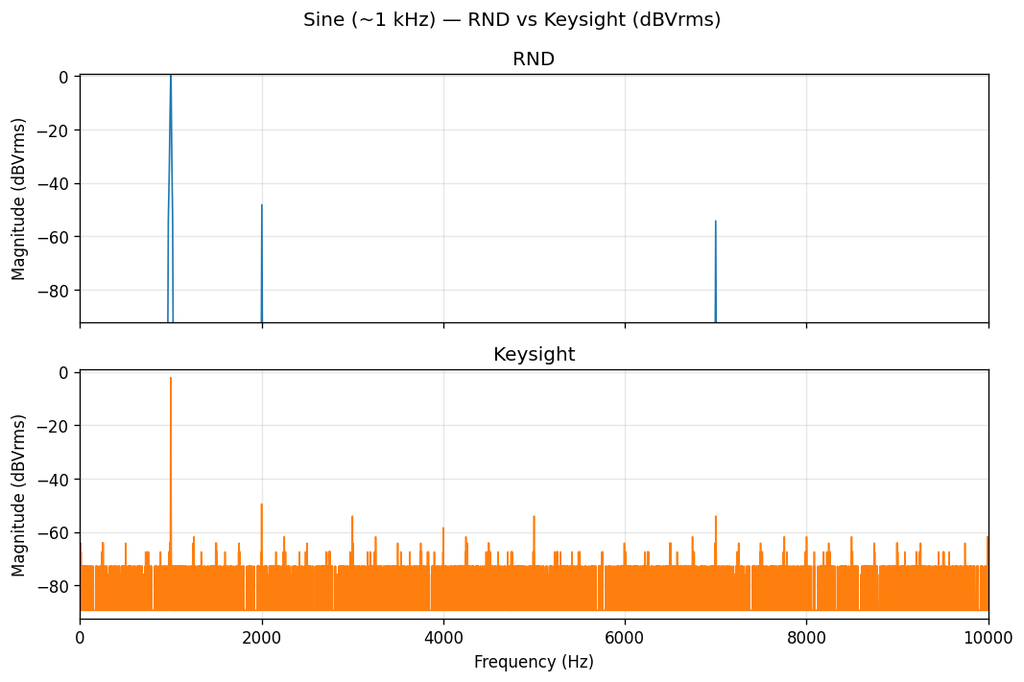

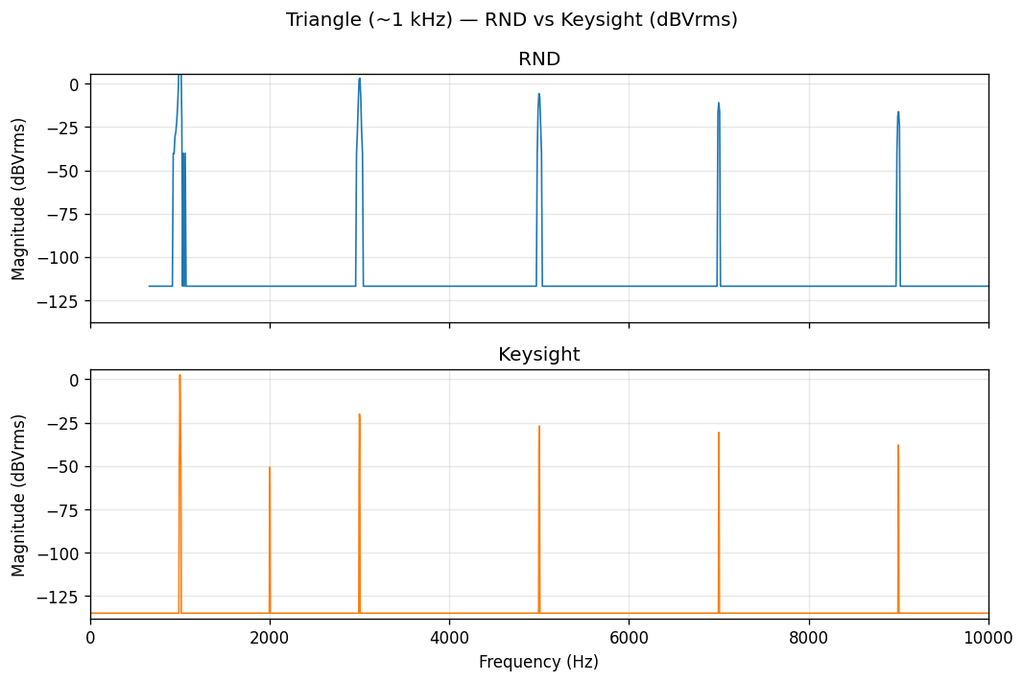

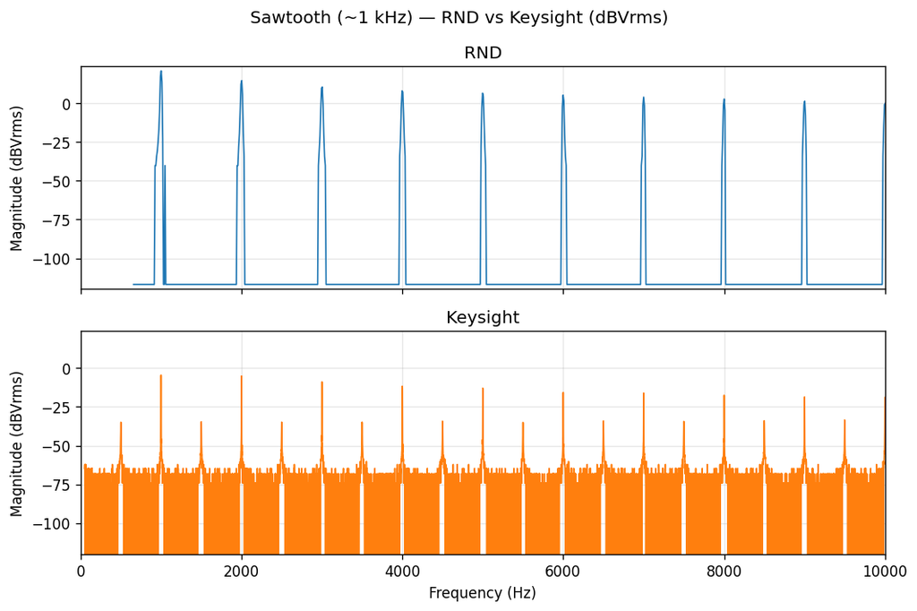

```python
# RND vs Keysight comparisons with smallest shared axes (dBVrms from Vrms)
# Load spectra and then plot using smallest common axes
import pandas as pd


def read_dbv(path):
    # Robust per-line parse: take last two numeric tokens per line as [freq, Vrms]
    freqs = []
    mags = []
    with open(path, 'r', encoding='utf-8', errors='ignore') as f:
        for line in f:
            if ';' not in line:
                continue
            parts = line.strip().split(';')
            nums = []
            for tok in reversed(parts):
                t = tok.replace(',', '.').strip()
                if not t:
                    continue
                try:
                    v = float(t)
                    nums.append(v)
                    if len(nums) == 2:
                        break
                except ValueError:
                    continue
            if len(nums) < 2:
                continue
            vrms = abs(nums[0])
            freq = nums[1]
            if not (np.isfinite(freq) and freq >= 0 and np.isfinite(vrms)):
                continue
            freqs.append(freq)
            mags.append(max(vrms, 1e-12))
    if not freqs:
        return pd.DataFrame({'freq_hz': [], 'dBVrms': []})
    freqs = np.array(freqs, dtype=float)
    mags = np.array(mags, dtype=float)
    dBV = 20.0 * np.log10(mags)
    df = pd.DataFrame({'freq_hz': freqs, 'dBVrms': dBV})
    df = df.sort_values('freq_hz').drop_duplicates(subset=['freq_hz']).reset_index(drop=True)
    return df

rnd_sine_df = read_dbv('RND_lab_sine_1khz_fft.csv')
key_sine_df = read_dbv('trace_sine_fft.csv')

rnd_tri_df = read_dbv('RND_lab_triangle_fft.csv')
key_tri_df = read_dbv('trace_triangle_fft.csv')

rnd_saw_df = read_dbv('RND_lab_saw_fft.csv')
key_saw_df = read_dbv('trace_saw_fft.csv')

# Short-circuit if any is empty
pairs = [
    ('Sine (~1 kHz) — RND vs Keysight (dBVrms)', rnd_sine_df, 'RND', key_sine_df, 'Keysight', 1000.0),
    ('Triangle (~1 kHz) — RND vs Keysight (dBVrms)', rnd_tri_df, 'RND', key_tri_df, 'Keysight', 1000.0),
    ('Sawtooth (~1 kHz) — RND vs Keysight (dBVrms)', rnd_saw_df, 'RND', key_saw_df, 'Keysight', 1000.0),
]

for title, d1, l1, d2, l2, f0h in pairs:
    if d1.empty or d2.empty:
        print(f"Skipping {title} due to empty data.")
        continue
    plot_pair_smallest_axes(title, d1, l1, d2, l2, f0_hint=f0h)
```

```python
# Common-axes helper: use smallest common x-range and smallest y-span (robust)
import numpy as np

def _common_axes_smallest(d1, d2, f0_hint=None, n_harm=10):
    # Expect pandas DataFrames with 'freq_hz' and 'dBVrms'
    f1 = np.asarray(d1['freq_hz'].to_numpy()) if 'freq_hz' in d1 else np.asarray([])
    y1 = np.asarray(d1['dBVrms'].to_numpy()) if 'dBVrms' in d1 else np.asarray([])
    f2 = np.asarray(d2['freq_hz'].to_numpy()) if 'freq_hz' in d2 else np.asarray([])
    y2 = np.asarray(d2['dBVrms'].to_numpy()) if 'dBVrms' in d2 else np.asarray([])

    # Preferred xmax by harmonics if f0_hint provided
    pref = n_harm * float(f0_hint) if (f0_hint is not None and f0_hint > 0) else None

    max1 = float(np.max(f1)) if f1.size else None
    max2 = float(np.max(f2)) if f2.size else None
    candidates = [x for x in [max1, max2, pref] if (x is not None and x > 0)]

    shared_xmax = min(candidates) if candidates else 0.0
    if shared_xmax <= 0.0:
        # fallback to any available max
        shared_xmax = max([x for x in [max1, max2] if x is not None] or [1.0])
    xmin = 0.0

    m1 = (f1 >= xmin) & (f1 <= shared_xmax) if f1.size else np.array([], dtype=bool)
    m2 = (f2 >= xmin) & (f2 <= shared_xmax) if f2.size else np.array([], dtype=bool)

    y1_slice = y1[m1] if (y1.size and np.any(m1)) else y1
    y2_slice = y2[m2] if (y2.size and np.any(m2)) else y2

    def span(arr):
        if arr.size:
            return float(np.nanmin(arr)), float(np.nanmax(arr)), float(np.nanmax(arr) - np.nanmin(arr))
        return -120.0, 20.0, 140.0

    y1_min, y1_max, span1 = span(y1_slice)
    y2_min, y2_max, span2 = span(y2_slice)

    if span1 <= span2:
        ymin, ymax = y1_min, y1_max
    else:
        ymin, ymax = y2_min, y2_max

    pad = 3.0
    return (xmin, shared_xmax), (ymin - pad, ymax + pad)
```

```python
# Generate first-10-harmonic tables (measurement vs theory)
from IPython.display import display
print("Sawtooth — input (trace_saw_fft.csv)")
display(table_10_harmonics('trace_saw_fft.csv', 'saw', F0=1000.0, N=10, apply_rc=False))
print("\nTriangle — input (trace_triangle_fft.csv)")
display(table_10_harmonics('trace_triangle_fft.csv', 'tri', F0=1000.0, N=10, apply_rc=False))
print("\nSine — input (trace_sine_fft.csv)")
display(table_10_harmonics('trace_sine_fft.csv', 'sin', F0=1000.0, N=10, apply_rc=False))
print("\nSawtooth — after RC (rc_fft_1khz.csv)")
display(table_10_harmonics('rc_fft_1khz.csv', 'saw', F0=1000.0, N=10, apply_rc=True))


# Optional: compact metric summaries for generator quality comparison (dBVrms)
rnd_sine  = summarize_metrics_dbv(load_fft_csv('RND_lab_sine_1khz_fft.csv'))
key_sine  = summarize_metrics_dbv(load_fft_csv('trace_sine_fft.csv'))
rnd_tri   = summarize_metrics_dbv(load_fft_csv('RND_lab_triangle_fft.csv'))
key_tri   = summarize_metrics_dbv(load_fft_csv('trace_triangle_fft.csv'))
rnd_saw   = summarize_metrics_dbv(load_fft_csv('RND_lab_saw_fft.csv'))
key_saw   = summarize_metrics_dbv(load_fft_csv('trace_saw_fft.csv'))


def print_metrics(name, m):
    print(f"{name}: f0={m['f0_hz']:.2f} Hz | Fundamental={m['fund_dBVrms']:.1f} dBVrms | THD={m['THD_dB']:.1f} dB | SFDR={m['SFDR_dB']:.1f} dB | Noise floor (med)={m['NoiseFloorMed_dBVrms']:.1f} dBVrms")


print("\nGenerator quality comparison (dBVrms metrics):")
print_metrics("RND — Sine", rnd_sine)
print_metrics("Keysight — Sine", key_sine)
print_metrics("RND — Triangle", rnd_tri)
print_metrics("Keysight — Triangle", key_tri)
print_metrics("RND — Sawtooth", rnd_saw)
print_metrics("Keysight — Sawtooth", key_saw)
```

```
Sawtooth — input (trace_saw_fft.csv)
```

|  | n | f_bin_Hz | meas_dBVrms | theory_dBVrms |
| --- | --- | --- | --- | --- |
| 0 | 1 | 1000.404357 | -4.482333 | 1.026103 |
| 1 | 2 | 1999.855041 | -5.122092 | -4.994497 |
| 2 | 3 | 3000.259398 | -8.846661 | -8.516322 |
| 3 | 4 | 3999.710081 | -11.708367 | -11.015097 |
| 4 | 5 | 5000.114439 | -12.986561 | -12.953297 |
| 5 | 6 | 5999.565122 | -16.037172 | -14.536922 |
| 6 | 7 | 6999.969479 | -16.069481 | -15.875858 |
| 7 | 8 | 8000.373837 | -17.509711 | -17.035697 |
| 8 | 9 | 8999.824520 | -18.607909 | -18.058748 |
| 9 | 10 | 10000.228878 | -18.931827 | -18.973897 |

```
Triangle — input (trace_triangle_fft.csv)
```

|  | n | f_bin_Hz | meas_dBVrms | theory_dBVrms |
| --- | --- | --- | --- | --- |
| 0 | 1 | 999.450685 | 2.641790 | 3.124305 |
| 1 | 2 | 1998.901369 | -50.664103 | NaN |
| 2 | 3 | 2998.352054 | -20.034010 | -15.960545 |
| 3 | 4 | 4997.253424 | -38.622506 | NaN |
| 4 | 5 | 5001.068121 | -26.950876 | -24.834495 |
| 5 | 6 | 5004.882818 | -60.207589 | NaN |
| 6 | 7 | 6999.969490 | -30.663626 | -30.679617 |
| 7 | 8 | 7003.784188 | -60.207589 | NaN |
| 8 | 9 | 8998.870860 | -37.927253 | -35.045395 |
| 9 | 10 | 9002.685557 | -46.226916 | NaN |

```
Sine — input (trace_sine_fft.csv)
```

|  | n | f_bin_Hz | meas_dBVrms | theory_dBVrms |
| --- | --- | --- | --- | --- |
| 0 | 1 | 1000.404357 | -2.102663 | 4.9485 |
| 1 | 2 | 1999.855041 | -49.487646 | NaN |
| 2 | 3 | 3000.259398 | -54.035016 | NaN |
| 3 | 4 | 3999.710081 | -58.373162 | NaN |
| 4 | 5 | 5000.114439 | -54.035016 | NaN |
| 5 | 6 | 5999.565122 | -89.342330 | NaN |
| 6 | 7 | 6999.969479 | -54.035016 | NaN |
| 7 | 8 | 8000.373837 | -61.773012 | NaN |
| 8 | 9 | 8999.824520 | -64.151500 | NaN |
| 9 | 10 | 10000.228878 | -72.787276 | NaN |

```
Sawtooth — after RC (rc_fft_1khz.csv)
```

|  | n | f_bin_Hz | meas_dBVrms | theory_dBVrms |
| --- | --- | --- | --- | --- |
| 0 | 1 | 1001.358032 | -0.417003 | 0.003643 |
| 1 | 2 | 1997.947692 | -9.055858 | -8.136987 |
| 2 | 3 | 2999.305724 | -13.886599 | -13.817135 |
| 3 | 4 | 4000.663756 | -18.198600 | -18.214411 |
| 4 | 5 | 5002.021787 | -22.476204 | -21.782140 |
| 5 | 6 | 5998.611448 | -25.088529 | -24.772041 |
| 6 | 7 | 6999.969479 | -27.336981 | -27.339369 |
| 7 | 8 | 8001.327511 | -29.835767 | -29.585763 |
| 8 | 9 | 8997.917171 | -32.601840 | -31.580898 |
| 9 | 10 | 9999.275203 | -33.761688 | -33.374370 |

```
Generator quality comparison (dBVrms metrics):
RND — Sine: f0=1001.36 Hz | Fundamental=4.5 dBVrms | THD=-51.7 dB | SFDR=-41.8 dB | Noise floor (med)=-128.9 dBVrms
Keysight — Sine: f0=999.45 Hz | Fundamental=-2.1 dBVrms | THD=-43.6 dB | SFDR=-47.4 dB | Noise floor (med)=-89.3 dBVrms
RND — Triangle: f0=1001.36 Hz | Fundamental=23.0 dBVrms | THD=-19.1 dB | SFDR=-19.8 dB | Noise floor (med)=-240.0 dBVrms
Keysight — Triangle: f0=999.45 Hz | Fundamental=2.6 dBVrms | THD=-21.5 dB | SFDR=-22.7 dB | Noise floor (med)=-240.0 dBVrms
RND — Sawtooth: f0=1001.36 Hz | Fundamental=20.9 dBVrms | THD=-3.1 dB | SFDR=-6.3 dB | Noise floor (med)=-240.0 dBVrms
Keysight — Sawtooth: f0=999.45 Hz | Fundamental=-4.5 dBVrms | THD=2.6 dB | SFDR=-0.6 dB | Noise floor (med)=-74.2 dBVrms
```

## Alignment to assignments (ELA24)

- 1a. Sawtooth 1 kHz, 5 Vpp, 0 V offset — measure the first 10 harmonics (dBVrms) and compare to theory.  
  Use the cell titled “ELA24 LAB COMPARISONS IN dBVrms” (Sawtooth — input) and/or `compare_plot()` to generate a figure/table.
- 1b. Triangle 1 kHz — measure 10 harmonics, compare to theory (odd n only).  
  Use the Triangle — input cell.
- 1c. Sine 1 kHz — expect only the fundamental; small extra lines may arise from distortion/leakage.  
  Use the Sine — input cell.
- 2. RC filter (R=8.2 kΩ, C=10 nF) with sawtooth — measure 10 harmonics at the output (dBVrms).  
     Use “Sawtooth — after RC (dBVrms)” and compare to theory multiplied by |H(jω)|.

## Appendix A — Image gallery (time and frequency domain)

#### Time-Domain Waveforms (Input Signals)

[output not shown]

#### FFT Spectra (Measured)

[output not shown]

#### RC Filter Frequency Response / Effect (Selected Frequencies)

[output not shown]

(Additional views) Example higher‑frequency time traces illustrating stronger attenuation:

[output not shown]

> If any image fails to render in exported PDF, ensure the images reside in the same directory as this notebook before conversion or embed them as base64.

## 5. Results (summary)

- All results are presented in dBVrms.
- Separate generator plots (RND vs Keysight) are shown for sine, triangle, and sawtooth.
- Tables list the first 10 harmonics (measurement vs theory) and the RC case for sawtooth.
- Sawtooth: Harmonics up to 10 kHz visible; amplitudes decay ≈ 1/n.
- Triangle: Odd harmonics only; amplitudes decay ≈ 1/n².
- Sine: Only the fundamental ideally; extra small peaks in practice stem from leakage/noise/distortion.
- RC filter: Attenuation increases with frequency (≈ −20 dB/dec above f_c); the time waveform becomes smoother.

## 6. Discussion

- **Sawtooth vs Triangle:** Sawtooth contains all harmonics (1/n); triangle only odd harmonics with faster decay (1/n²). This reflects sharp edges vs smoother ramps.
- **Sine:** Ideally only one spectral line; extra lines indicate window leakage, noise floor, or source distortion.
- **RC filter:** The predicted attenuation (20\log_{10}|H|) matches the trend you should observe. Deviations arise from probe loading, FFT bin resolution, window choice, and vertical scaling in dBVrms.
- **Phase:** The increasing negative phase with frequency explains the smoothing in time domain (harmonics lag more than the fundamental).

## 7. Conclusions

- Fourier series predictions for sawtooth, triangle, and sine match the expected spectral trends and harmonic content.
- The RC low-pass attenuates higher harmonics as predicted, yielding a smoother output waveform.
- Remaining differences are consistent with practical measurement limitations and FFT parameter choices.

## References

- H. Hallenberg, *Signalbehandling och kommunikationssystem*, Yrgo, 2021.
- ELA24 – *Laboration: Frekvensanalys* (Lab PM) and *Ledning Fourierlabben* (guidance notes).
- Keysight/Tektronix oscilloscope FFT documentation (Hann window, dBVrms scaling).
- Standard RC low-pass theory (jω method, Bode magnitude/phase).

```python
# Diagnostics: inspect structures used in comparisons
objs = {'rnd_sine': 'rnd_sine', 'key_sine': 'key_sine', 'rnd_tri': 'rnd_tri', 'key_tri': 'key_tri', 'rnd_saw': 'rnd_saw', 'key_saw': 'key_saw'}
for name, var in objs.items():
    try:
        o = globals().get(var, None)
        print(f"{name}: type={type(o)}")
        if isinstance(o, dict):
            print(f"  keys: {list(o.keys())[:6]}")
            if 'df' in o and hasattr(o['df'], 'head'):
                print(f"  df columns: {list(o['df'].columns)}  rows={len(o['df'])}")
        elif hasattr(o, 'head'):
            print(f"  df-like columns: {list(o.columns)}  rows={len(o)}")
    except Exception as e:
        print(f"{name}: error {e}")
```

```
rnd_sine: type=<class 'dict'>
  keys: ['f0_hz', 'fund_dBVrms', 'THD_dB', 'SFDR_dB', 'NoiseFloorMed_dBVrms']
key_sine: type=<class 'dict'>
  keys: ['f0_hz', 'fund_dBVrms', 'THD_dB', 'SFDR_dB', 'NoiseFloorMed_dBVrms']
rnd_tri: type=<class 'dict'>
  keys: ['f0_hz', 'fund_dBVrms', 'THD_dB', 'SFDR_dB', 'NoiseFloorMed_dBVrms']
key_tri: type=<class 'dict'>
  keys: ['f0_hz', 'fund_dBVrms', 'THD_dB', 'SFDR_dB', 'NoiseFloorMed_dBVrms']
rnd_saw: type=<class 'dict'>
  keys: ['f0_hz', 'fund_dBVrms', 'THD_dB', 'SFDR_dB', 'NoiseFloorMed_dBVrms']
key_saw: type=<class 'dict'>
  keys: ['f0_hz', 'fund_dBVrms', 'THD_dB', 'SFDR_dB', 'NoiseFloorMed_dBVrms']
```

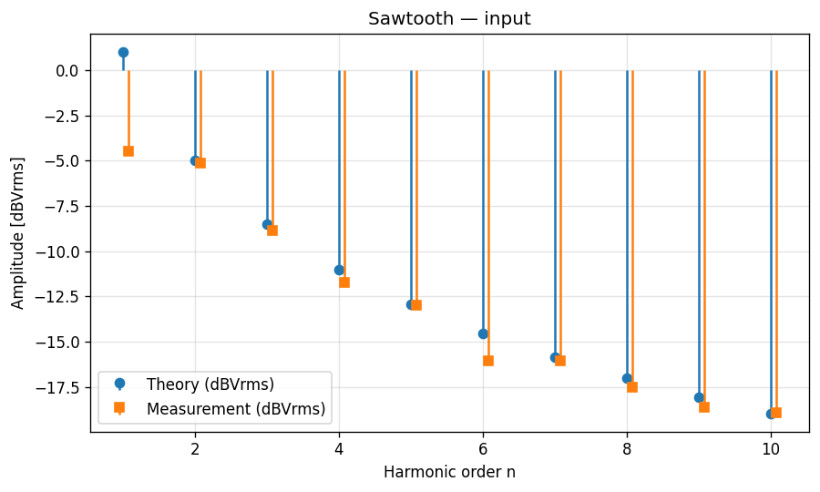

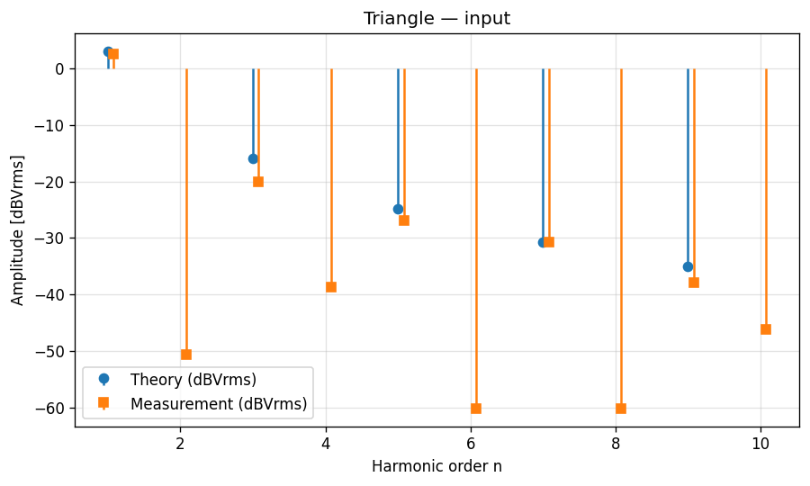

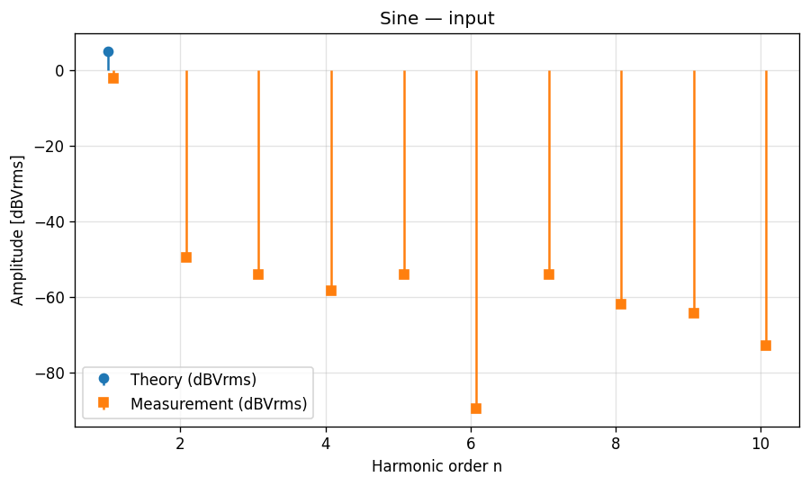

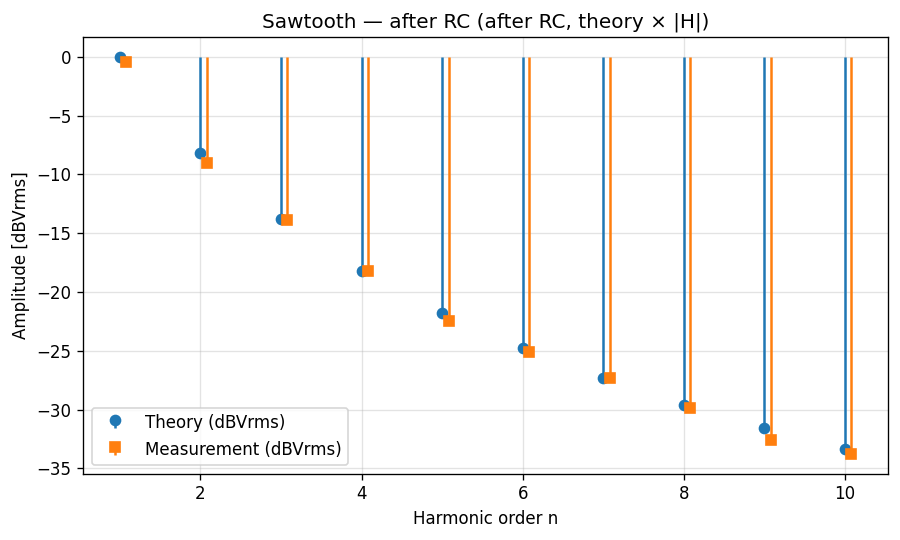

|  | n | f_target_Hz | f_bin_Hz | meas_dBVrms | f_Hz | theory_dBVrms | err_dB |
| --- | --- | --- | --- | --- | --- | --- | --- |
| 0 | 1 | 1000.0 | 1001.358032 | -0.417003 | 1000.0 | 0.003643 | -0.420646 |
| 1 | 2 | 2000.0 | 1997.947692 | -9.055858 | 2000.0 | -8.136987 | -0.918872 |
| 2 | 3 | 3000.0 | 2999.305724 | -13.886599 | 3000.0 | -13.817135 | -0.069463 |
| 3 | 4 | 4000.0 | 4000.663756 | -18.198600 | 4000.0 | -18.214411 | 0.015812 |
| 4 | 5 | 5000.0 | 5002.021787 | -22.476204 | 5000.0 | -21.782140 | -0.694065 |
| 5 | 6 | 6000.0 | 5998.611448 | -25.088529 | 6000.0 | -24.772041 | -0.316488 |
| 6 | 7 | 7000.0 | 6999.969479 | -27.336981 | 7000.0 | -27.339369 | 0.002388 |
| 7 | 8 | 8000.0 | 8001.327511 | -29.835767 | 8000.0 | -29.585763 | -0.250004 |
| 8 | 9 | 9000.0 | 8997.917171 | -32.601840 | 9000.0 | -31.580898 | -1.020942 |
| 9 | 10 | 10000.0 | 9999.275203 | -33.761688 | 10000.0 | -33.374370 | -0.387317 |

```python
# Keep: Theory vs measurement plots (dBVrms)
# Uses existing compare_plot() to show first N harmonics vs theory
compare_plot('trace_saw_fft.csv', waveform='saw', apply_rc_to_theory=False, title='Sawtooth — input')
compare_plot('trace_triangle_fft.csv', waveform='tri', apply_rc_to_theory=False, title='Triangle — input')
compare_plot('trace_sine_fft.csv', waveform='sin', apply_rc_to_theory=False, title='Sine — input')
# After RC: theory multiplied by |H(jω)|
compare_plot('rc_fft_1khz.csv', waveform='saw', apply_rc_to_theory=True, title='Sawtooth — after RC')
```

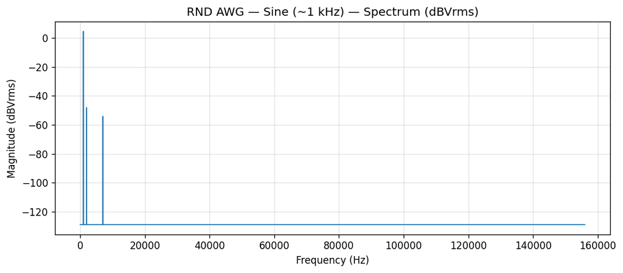

```python
# Quick test plot: RND AWG sine (~1 kHz) spectrum in dBVrms
import matplotlib.pyplot as plt

# Uses earlier helper load_fft_csv()
rnd_sine = load_fft_csv('RND_lab_sine_1khz_fft.csv', add_db=True)

plt.figure(figsize=(9, 4))
plt.plot(rnd_sine['freq_hz'], rnd_sine['dBVrms'], lw=1.0, color='C0')
plt.title('RND AWG — Sine (~1 kHz) — Spectrum (dBVrms)')
plt.xlabel('Frequency (Hz)')
plt.ylabel('Magnitude (dBVrms)')
plt.grid(True, alpha=0.35)
plt.tight_layout()
plt.show()
```